# Gender Representation in Film

Amalin Sorajja, Clarisa Faria Gomez, Mateo Useche

12-16-2023

> Title & Description

Barbie Land or Ken Land: The Evolution of Women in Film. Amalin, Clarisa, & Mateo. We are working on visualizing the relationship between women’s representation and movie elements.

It is well known that women representation in Hollywood, whether it is female-led movies percentage or percentage of female dialogue in the media, is significantly underrepresented. However, it is well known, and even surprising, that movies with a female lead still have low levels of female dialogue. For example, Mulan, a movie about a princess and women empowerment only has 25% female dialogue which is astounding given that the main character is a woman. We want to know if Mulan was an outlier or if this relationship pertains to more movies. Moreover, after our expert meeting with Actor and Director Laura Innes, she hinted at a potential source for this problem rooted in the percentage of female crew – or, more accurately, the lack of female crew in movies.

Therefore, we begin our research by asking how has the representation of women in film changed over time and how does this representation relate to movie factors like budget, revenue, and crew makeup. It is important for future policymaking and research to understand the relationships and factors that affect women representation in the film industry. Pointing out the lack of gender parity is not enough. We hope that showing women’s representation over time can help actively lead to more programs or investment for women to have more access into the film industry.

As mentioned above, gender inequality is extensively explored in the literature. Yang (2020) finds that female directors and producers are essential for an increase in women representation in the film industry. Furthermore, Erigha (2015) finds that Hollywood’s under-representation of racial and ethnic diversity leads to reinforcement of stereotypes. Feel free to read more on the articles cited below.

Erigha, M. (2015). Race, Gender, Hollywood: Representation in Cultural Production and Digital Media’s Potential for Change. Sociology Compass, 9(1), 78–89. https://doi.org/10.1111/soc4.12237

Yang, L., Xu, Z., & Luo, J. (2020). Measuring Female Representation and Impact in Films over Time. ACM/IMS Transactions on Data Science, 1(4), 1–14. https://doi.org/10.1145/3411213

> Data Sources

Our final dataset, spanning the years 1970 to 2013, comprises three distinct datasets merged to offer a comprehensive cinematic repository. The Movies Metadataset (1970-2020) contributes details on 45,000 films, encompassing essential information such as movie titles, cast, crew names, and genders. The Gender Dialogue Proportions Dataset (1925-2015), featuring 2,000 movies, delves into gender representation through dialogue proportions. The Budget, Revenue, and Bechdel Test Levels Dataset (1970-2013) sheds light on financial and gender dynamics for 1,800 films. Through merging based on shared movie titles, we created a unified dataset of 800 movies, incorporating key variables like cast and crew details, gender dialogue proportions, budget, revenue, and Bechdel Test levels. This organized dataset facilitates the exploration of cinematic trends, financial performance, and gender dynamics across a substantial time frame.

> Research Question

How has the representation of women in film changed over time and how does this representation relate to these movie factors: Budget, Revenue, Crew Makeup.

> Visualizations

Our first interest was to see how female representation has changed over time. We used two methods of looking at this evolution.

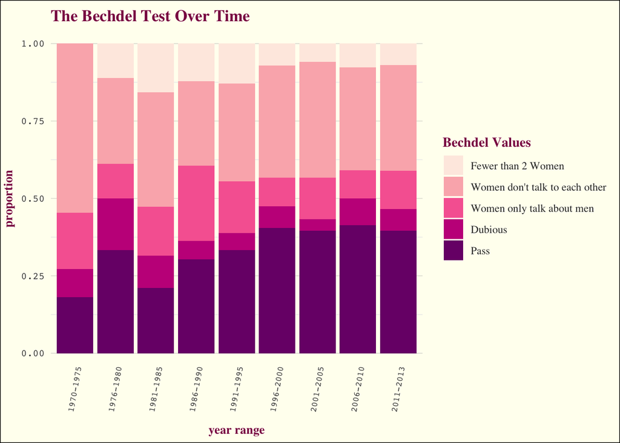

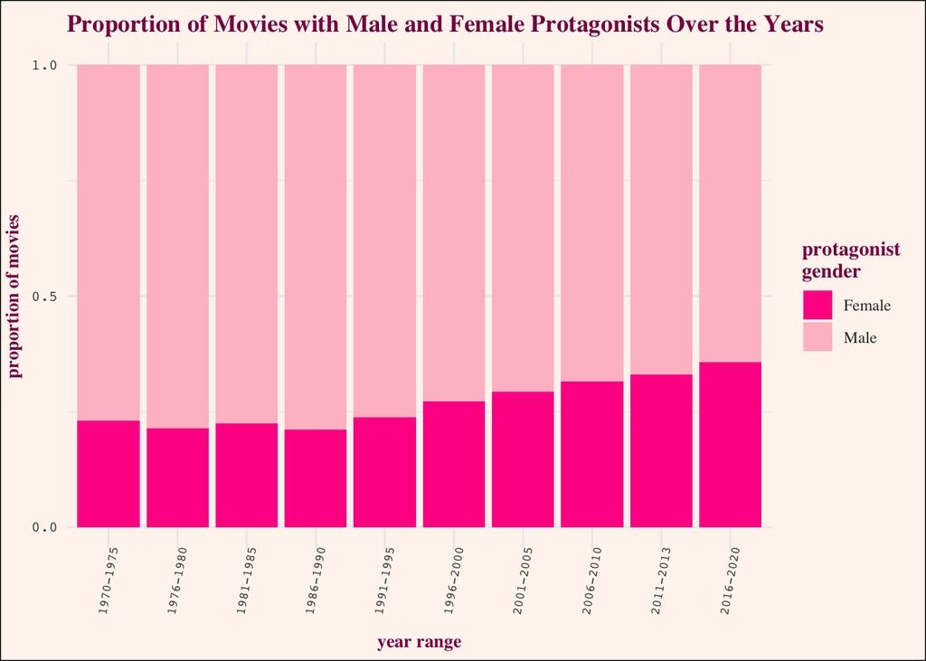

The first measure of representation we observed was the Bechdel Test. We have many Bechdel values that movies may classify as: movies that have fewer than two women, movies that have at least two women but the women don’t talk to each other, movies that have at least two women who talk to each other only about men, movies that have an unclear pass, movies that have at least two women who talk to each other about something other than a man. We were interested to see if initiatives like the Bechdel Test have encouraged a wider range of dialogue for women. We can see in this visualization that since it was created in 1985, there has been a steady increase in the proportion of movies that have passed the test. We can determine from this measure that female representation has expanded in terms of dialogue over these years.

Another way we observed the evolution of female representation was looking at the proportion of female-led movies and male-led movies. We can see in this stacked bar plot where the brighter pink shows the proportion of female-led movies, that this proportion has increased from about 23 per cent to 35 per cent. Though it does not reach parity, we can still observe an increase.

Based on these visualizations, we can conclude that female representation has increased over the years 1970 to 2013. Now we want to look at movie elements that may be associated with this increase.

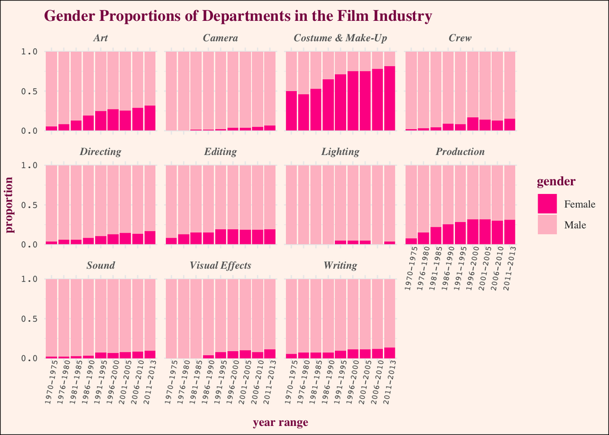

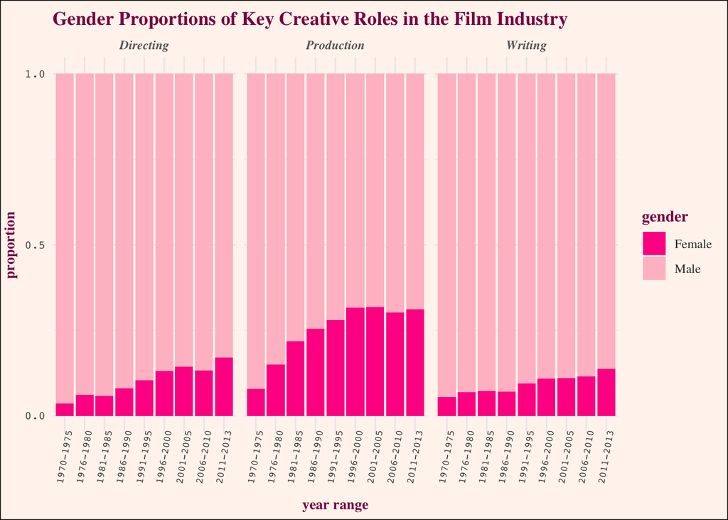

As our expert suggested, we decided to take a look at crew composition. First, we observed the proportion of female crew members and male crew members across all crew departments. From these stacked bar plots, we can see that each department is very male-dominated, all with the exception of the Costume & Makeup department. The good news is that we are seeing an increase in the proportion of female crew members in almost every department.

If we take a closer look at key creative roles - in other words, leadership roles - of directing, producing, and writing, we see a steady increase of female crew member proportions in directing and writing and a big increase in producing. This increase may be reflective of the increase in casting and female-led movies (producing) and the increased range of dialogue (writing).

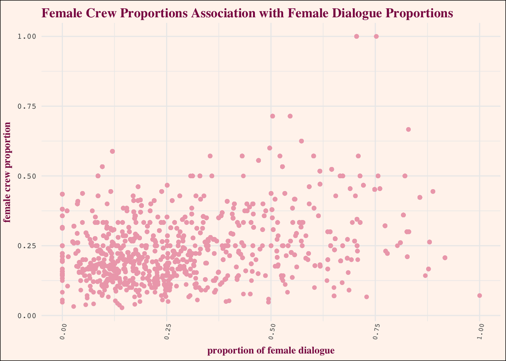

We also took a deeper look at the relationship between the proportion of female dialogue in movies and female crew proportion. We see a positive association here. There is a high density of movies in the lower left quadrant, meaning that there are a lot of movies with a low proportion of female dialogue and a low proportion of female crew. If we look at the extreme (x=0), we see there are a good amount of movies that have no female dialogue. What is interesting is that even movies with a significant amount of female crew (y > 0.25), there is still no female representation whatsoever in some of those movies.

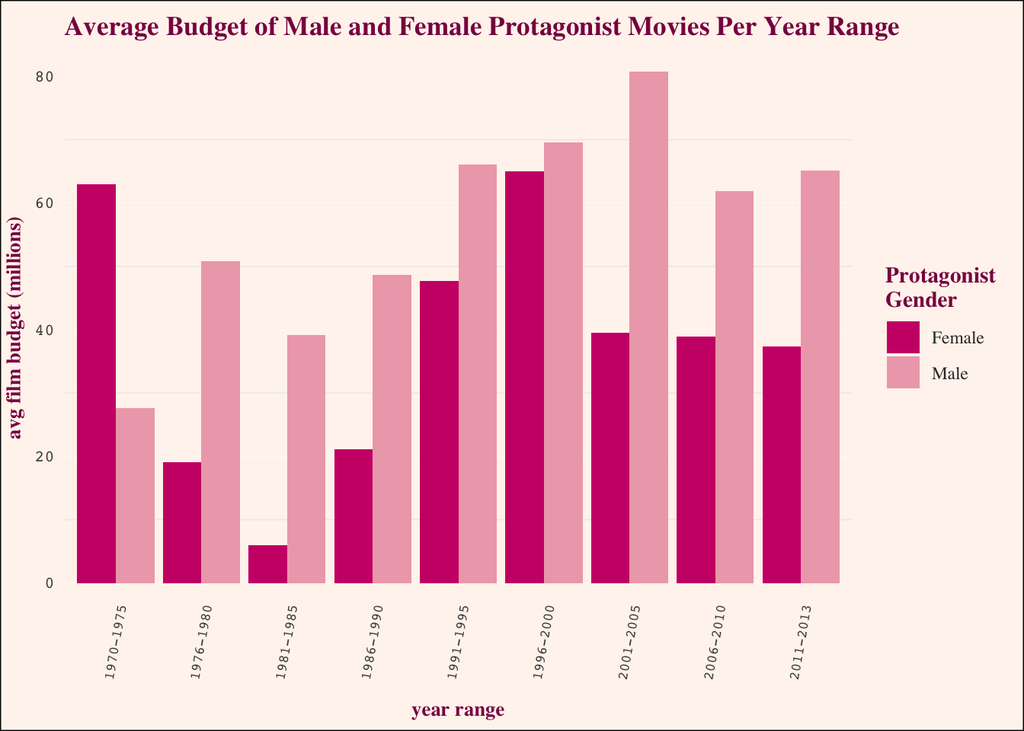

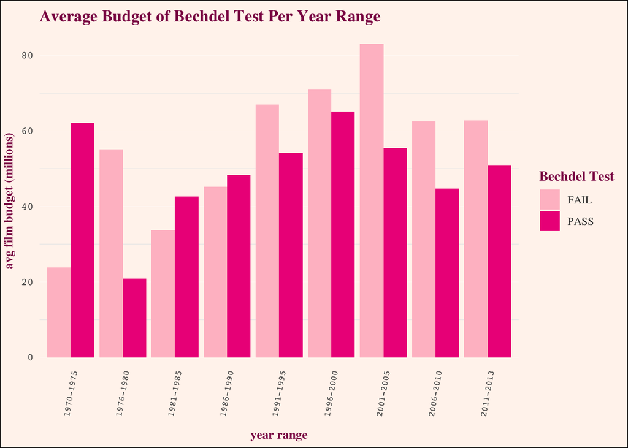

We also analyzed the relationship between movie budget and female representation in terms of female protagonists and movies that pass or fail the Bechdel Test. For the visualization involving protagonists, we grouped by year range, then by male-led movies and female-led movies and took the average budget for each of those groups. We have light pink columns representing male-led movies, and bright pink columns representing female-led ones. We can observe a trend here, where the average budget for male-led movies tends to be greater than that of female-led movies. One outlier is the 1970-1975 year range, where the average budget for female-led movies is a lot higher than the male-led movies. For this year range, there is only one female-led movie, and 10 male-led movies. Therefore, this dataset may not be a good representation for movies released during that year range.

For the visualization involving budget and movies that pass or fail the Bechdel Test, we again grouped by year range, movies that passed the test and movies that failed, and took the average budget of each of those groups. The pattern in this plot is not as stark as the one with protagonist gender, but we are seeing movies that fail the Bechdel Test seem to have higher average budgets. In other words, movies that have limited or less valuable female dialogue tend to have higher budgets on average.

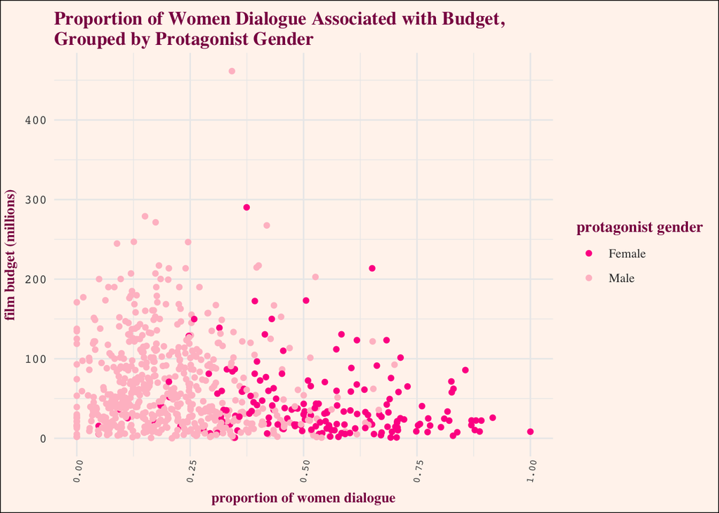

Our final visualization involving budget is a scatter plot of the relationship between the proportion of female dialogue and film budget, colored by protagonist gender. We observe a greater amount of movies that are male-led and condensed around low female dialogue values. The scatter plot is slightly right-skewed, meaning that higher film budgets tend to favor movies with low proportions of female dialogue.

We can see a flaw in looking at protagonist gender as a measure of representation. We see a lot of male-led movies with 100 per cent male dialogue, but only one female-led movie that has 100 per cent female dialogue, meaning that though a movie is female-led, it does not necessarily mean they are receiving the same representation (dialogue) male-led movies receive (think of Mulan for example, female-led movie but low female dialogue).

Looking at budget overall, we can see a slight association with female representation. This is a negative association, meaning that as budget increases, we observe a lower amount of female representation in a movie.

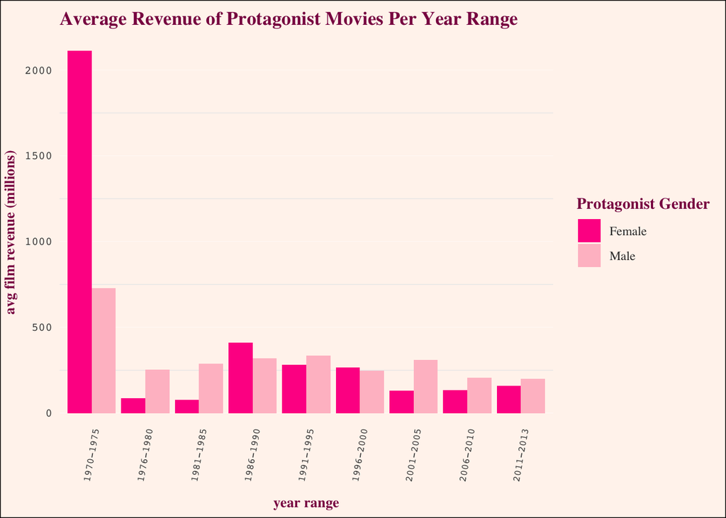

The final movie component we wanted to observe was film revenue. We were interested to see how female representation performs among viewership. In the visualization above, we used the same method as looking at budget, where we grouped by year range and by protagonist gender and took the average revenue of those groups. We found that revenue does not consistently have a distinct pattern among female-led movies and male-led movies.

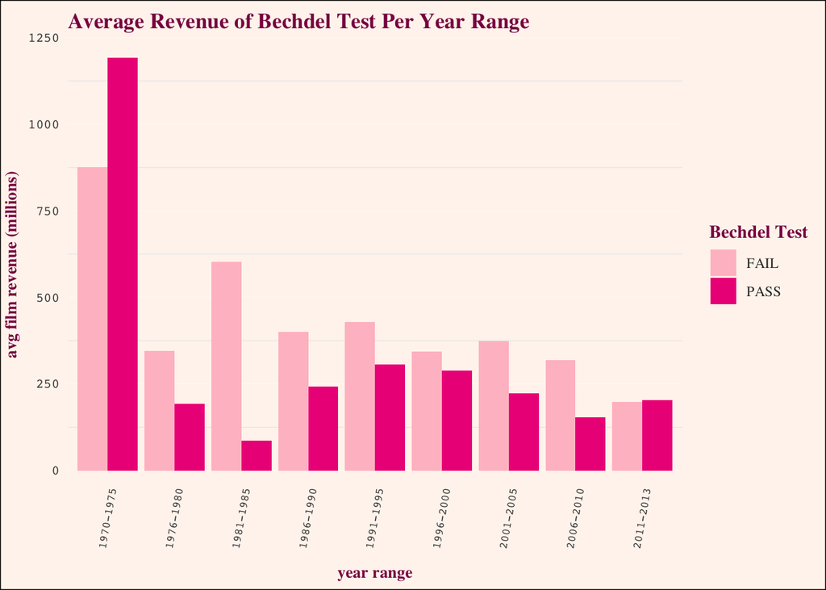

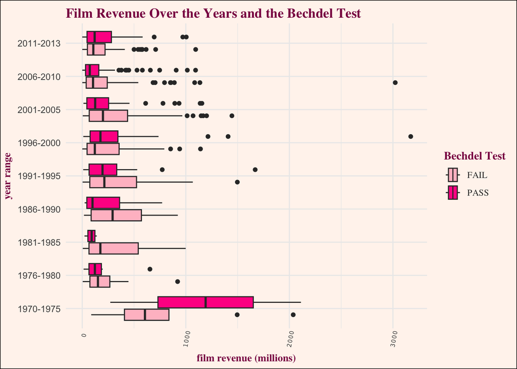

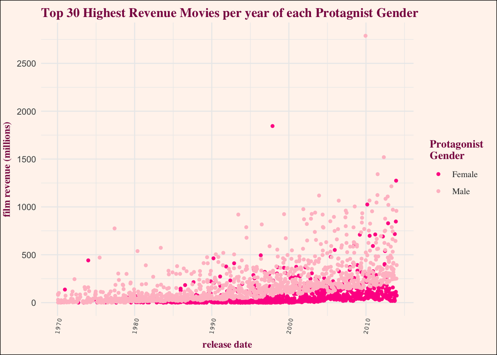

In our final visual analysis of revenue, we have a scatter plot of the top 30 highest revenue of female-led movies and top 30 of male-led movies each year. We can see that the groups are very divided, where the revenue of top 30 highest male-led movies tend to be higher than that of top 30 highest female-led movies. Therefore, we also see a negative association between film revenue and female representation.

> Limitations

There are potential limitations from our analysis. First, our sample of movies is only from the United States; therefore, we are unable to extrapolate any of our results to an international scenario. It would be beneficial for future research to look into gender representation in a different geographic context. Second, we are lacking recent movie data. Our data’s most recent year available is from 2013, and it would be interesting to look at how gender representation has evolved over the last decade. Third, our definition of gender representation is very quantitative and it does not stratify gender representation by race. Consequently, our analysis could miss some nuance from taking a more complete and qualitative approach to answering these questions. Future research should look at the intersection between gender representation and race, as Hollywood is a predominantly white industry. Finally, our analysis does not explore how women are portrayed in films. For instance, even if women representation increases through time, we cannot say if women are still playing stereotypical gender roles. We hope that our analysis can serve as a case study for future research with a more diverse set of data to answer these questions.

> Team Member’s Contributions

All team members participated in data collecting, cleaning, and merging as well as completing visual analysis of each movie component. Separate contributions are listed below.

Amalin: Presentation Layout, Visualizations of Crew Composition, Overall Conclusions/Analysis Mateo: Limitations, Visualizations of Budget & Female Representation Evolution, Summary of Literature Review Clarisa: Contacted Laura, Visualizations of Revenue, Presentation Game, Motivation of the project & Relevance